# Statistical analysis in RStudio

# INTRODUCTION

The main objective of statistical analysis is to find the correlation and Trends of seal abundance using the serial dataset.

Firstly we will download the data and convert it into a csv file and then import data into R studio after importing data We will read the data and convert the data into data frame Which will import data into rows and columns. If we check the head of data we can find There are 5 columns 210 observations.

- The first column represents the year, each row consists of the year from 2007 to 2010.
- The second column represents the month of a specific year; there are 15 unique variables if it presents the month of a particular Year.
- The third column represents a site which consists of 7 unique variables A,B,C,D,Split and Wall.
- The fourth column represents species which have true unique species Harbour and grey.
- The final column represents the average count of each species in a particular year year and month each variable has a unique count value.

After looking at the column if we check the structure of data,the first four columns represent the character data type, the last column that is average count represents the numerical data type.

After getting familiar with the data set ,the first four column data type should be changed to factor type as in which column the variable of rows are repetitive.

| Summer | Year.Month | Site | Species | average.count |
| --- | --- | --- | --- | --- |
| summer-2007 | 2007.Jun | A | HARBOUR | 14.1 |
| summer-2007 | 2007.Jun | B | HARBOUR | 0.3 |
| summer-2007 | 2007.Jun | C | HARBOUR | 14.7 |
| summer-2007 | 2007.Jun | Spit | HARBOUR | 0.1 |
| summer-2007 | 2007.Jun | Wall | HARBOUR | 0.7 |
| summer-2007 | 2007.Jun | D | HARBOUR | 0.0 |

```
## 'data.frame':    210 obs. of  5 variables:
##  $ Summer       : chr  "summer-2007" "summer-2007" "summer-2007" "summer-2007" ...
##  $ Year.Month   : chr  "2007.Jun" "2007.Jun" "2007.Jun" "2007.Jun" ...
##  $ Site         : chr  "A" "B" "C" "Spit" ...
##  $ Species      : chr  "HARBOUR" "HARBOUR" "HARBOUR" "HARBOUR" ...
##  $ average.count: num  14.1 0.3 14.7 0.1 0.7 0 0 0.3 0 2.6 ...
```

# MATERIALS AND METHODS

## QQNORM Test

After checking rows and columns of data, it can be easily identified that only the average.count data column has numerical value. If we check the normality of the average.count column using the qqnorm() function,The Below visualization data represents the relationship between the theoretical and sample quantities which derive the plotted data is distinctly curved and determines that the data is not normal.

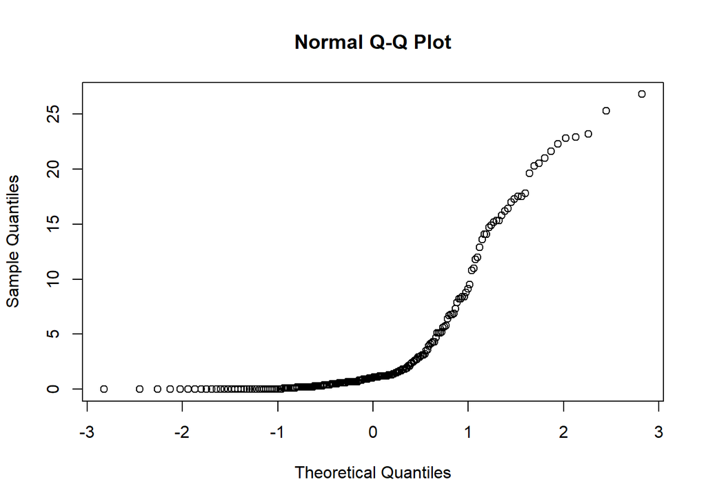

```
##
##  Shapiro-Wilk normality test
##
## data:  data$average.count
## W = 0.67749, p-value < 2.2e-16
```

Since the data is not significant,in order to find out The number of seals are significantly different for each year plot the data of average count of number of seals for each year but before that we have to change the data type of the first four columns into factors.

```
## 'data.frame':    210 obs. of  5 variables:
##  $ Summer       : Factor w/ 4 levels "2007","2008",..: 1 1 1 1 1 1 1 1 1 1 ...
##  $ Year.Month   : Factor w/ 15 levels "2007.Aug","2007.Jul",..: 3 3 3 3 3 3 3 3 3 3 ...
##  $ Site         : Factor w/ 7 levels "A","B","C","D",..: 1 2 3 6 7 4 5 1 2 3 ...
##  $ Species      : Factor w/ 2 levels "GREY","HARBOUR": 2 2 2 2 2 2 2 1 1 1 ...
##  $ average.count: num  14.1 0.3 14.7 0.1 0.7 0 0 0.3 0 2.6 ...
```

After changing the data type we can find that the summer column has aur factor levels, Year. month column has 15 factor levels, the site column as 7 factor level and and the species column two factor levels.

In order to find out this we can transfer some non parametric test like kruskal Wallis rank sum test Which help us to determine the overall correlation and statistical Association for data by providing a chi-squared interpretation and a p-value.

But before if we check the below graph, we can see that the 2009 has highest average count followed by 2010 and the least averge count is 2008.

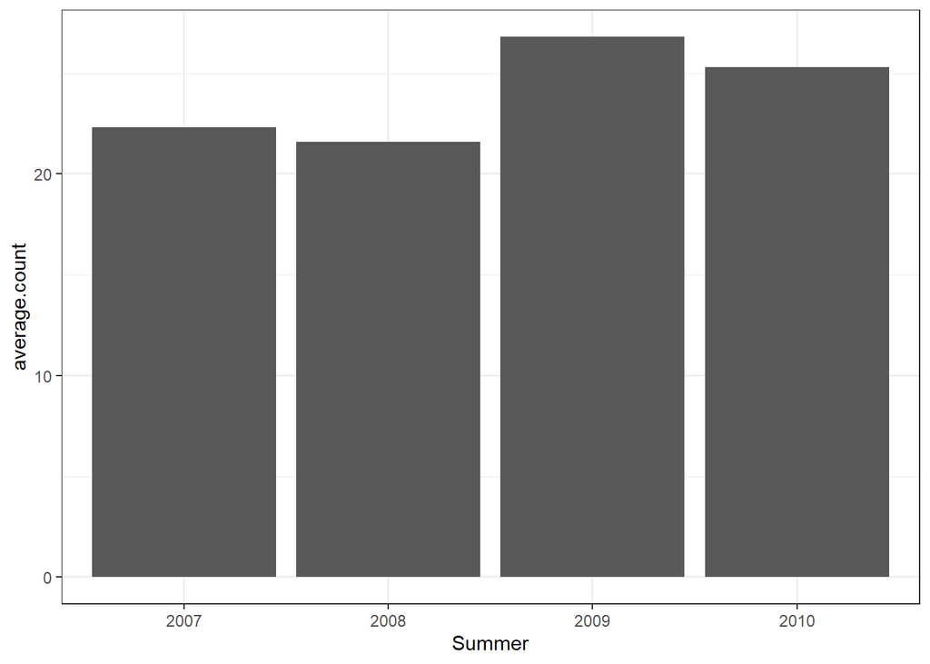

## Kruskal-Wallis Test

In order to perform the Krukals-wallis test, we need to use the kruskal.test() function.

```
##
##  Kruskal-Wallis rank sum test
##
## data:  data$average.count and data$Summer
## Kruskal-Wallis chi-squared = 6.236, df = 3, p-value = 0.1007
```

Firstly, if we explore the overall difference between all the variables we can see that The P value is greater than 0.01, thus we can say that it There is no significant difference between the groups. In order to explore this into more detail to find out that the pairs of groups are different or not, will use pairwise willox test For comparing different group levels for multiple testing.

```
##
##  Pairwise comparisons using Wilcoxon rank sum test with continuity correction
##
## data:  data$average.count and data$Summer
##
##      2007 2008 2009
## 2008 0.89 -    -
## 2009 0.20 0.43 -
## 2010 0.43 0.64 0.89
##
## P value adjustment method: holm
```

In the above test we can see that the P value for significant years is quite normal. further, providing an adjustment method we can avoid the false positive results in order to see more accuracy.

```
##
##  Pairwise comparisons using Wilcoxon rank sum test with continuity correction
##
## data:  data$average.count and data$Summer
##
##      2007 2008 2009
## 2008 0.54 -    -
## 2009 0.17 0.17 -
## 2010 0.17 0.32 0.75
##
## P value adjustment method: BH
```

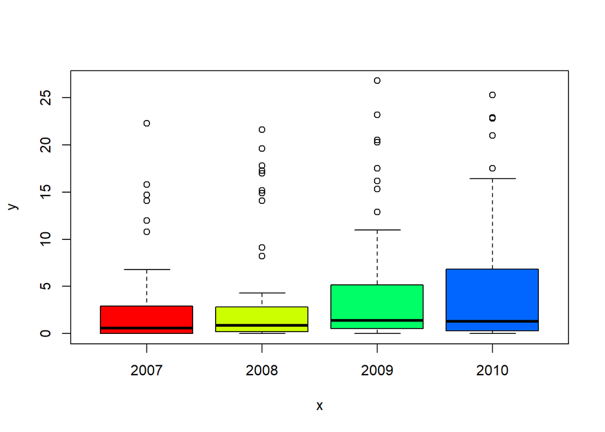

After this we can check the presence of the seals for each month in a particular year. We might be able to explore the difference for the presence of seals in each month of the year.

The plot below shows the values of average count for each month of particular year.We can see that in 2009 Aug,the number of species were counted the most and in 2010 Sep the species were counted the least. But in order to find significant relationship we need to explore the data and run test accordingly.

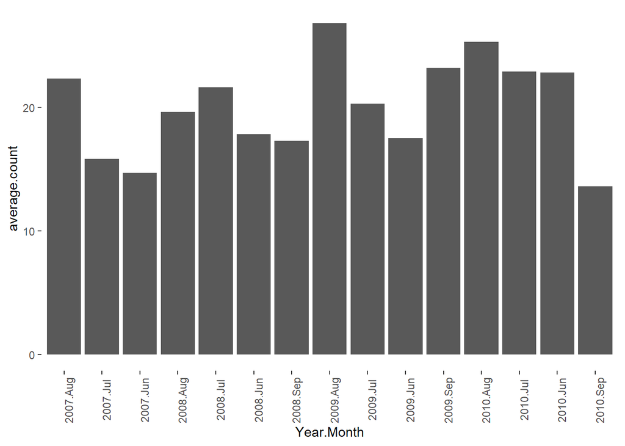

### Kruskal Test For each month

If we consider the year 2007, we can see that there is no significant difference between different months.The p-value is greater than 0.05 and the adjusted p value is also greater than 0.05.

```
##
##  Kruskal-Wallis rank sum test
##
## data:  data$average.count[data$Summer == "2007"] and data$Year.Month[data$Summer == "2007"]
## Kruskal-Wallis chi-squared = 1.3113, df = 2, p-value = 0.5191
```

```
##
##  Pairwise comparisons using Wilcoxon rank sum test with continuity correction
##
## data:  data$average.count[data$Summer == "2007"] and data$Year.Month[data$Summer == "2007"]
##
##          2007.Aug 2007.Jul
## 2007.Jul 0.63     -
## 2007.Jun 0.63     0.63
##
## P value adjustment method: BH
```

If we consider the year 2008, we can see that there is no significant difference between different months.

```
##
##  Kruskal-Wallis rank sum test
##
## data:  data$average.count[data$Summer == "2008"] and data$Year.Month[data$Summer == "2008"]
## Kruskal-Wallis chi-squared = 0.86061, df = 3, p-value = 0.8349
```

```
##
##  Pairwise comparisons using Wilcoxon rank sum test with continuity correction
##
## data:  data$average.count[data$Summer == "2008"] and data$Year.Month[data$Summer == "2008"]
##
##          2008.Aug 2008.Jul 2008.Jun
## 2008.Jul 0.93     -        -
## 2008.Jun 0.93     0.93     -
## 2008.Sep 0.93     0.93     0.93
##
## P value adjustment method: BH
```

```
##
##  Kruskal-Wallis rank sum test
##
## data:  data$average.count[data$Summer == "2009"] and data$Year.Month[data$Summer == "2009"]
## Kruskal-Wallis chi-squared = 0.42051, df = 3, p-value = 0.936
```

```
##
##  Pairwise comparisons using Wilcoxon rank sum test with continuity correction
##
## data:  data$average.count[data$Summer == "2009"] and data$Year.Month[data$Summer == "2009"]
##
##          2009.Aug 2009.Jul 2009.Jun
## 2009.Jul 1        -        -
## 2009.Jun 1        1        -
## 2009.Sep 1        1        1
##
## P value adjustment method: BH
```

```
##
##  Kruskal-Wallis rank sum test
##
## data:  data$average.count[data$Summer == "2010"] and data$Year.Month[data$Summer == "2010"]
## Kruskal-Wallis chi-squared = 2.5001, df = 3, p-value = 0.4753
```

```
##
##  Pairwise comparisons using Wilcoxon rank sum test with continuity correction
##
## data:  data$average.count[data$Summer == "2010"] and data$Year.Month[data$Summer == "2010"]
##
##          2010.Aug 2010.Jul 2010.Jun
## 2010.Jul 0.75     -        -
## 2010.Jun 0.60     0.96     -
## 2010.Sep 0.96     0.60     0.60
##
## P value adjustment method: BH
```

## Specices Abundance

Considering the data and previous stats we found that there were no significant difference for each month but in order to get detailed information about the species we can check the count of each type of species and find out the non-significant relationship of the data .

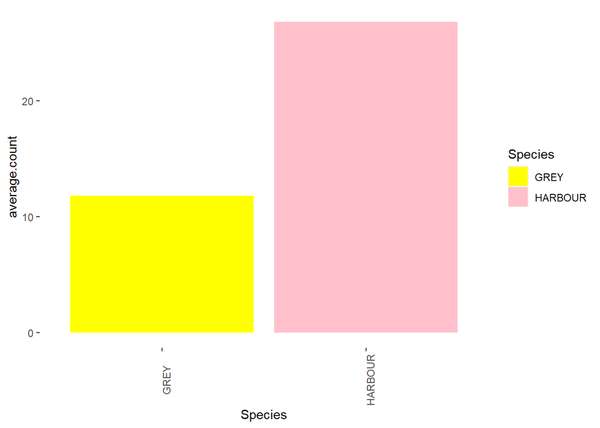

```
##
##  Kruskal-Wallis rank sum test
##
## data:  data$average.count and data$Species
## Kruskal-Wallis chi-squared = 18.66, df = 1, p-value = 1.562e-05
```

```
##
##  Pairwise comparisons using Wilcoxon rank sum test with continuity correction
##
## data:  data$average.count and data$Species
##
##         GREY
## HARBOUR 1.6e-05
##
## P value adjustment method: BH
```

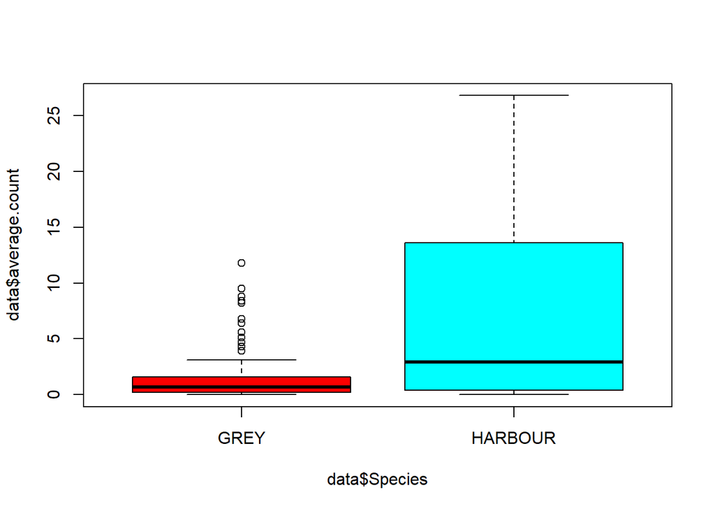

Also, we can explore data in more detailed way in order to find out significant difference of species for each year.

If we look at the below stats, we can clearly see the p-value for 2007 year is greater than 0.05 and adjusted p-value is is also greater than 0.05 which derives there is slightest significance difference in the Species

```
##
##  Kruskal-Wallis rank sum test
##
## data:  data$average.count[data$Summer == "2007"] and data$Species[data$Summer == "2007"]
## Kruskal-Wallis chi-squared = 3.2976, df = 1, p-value = 0.06938
```

```
##
##  Pairwise comparisons using Wilcoxon rank sum test with continuity correction
##
## data:  data$average.count[data$Summer == "2007"] and data$Species[data$Summer == "2007"]
##
##         GREY
## HARBOUR 0.071
##
## P value adjustment method: BH
```

Again, If we look at the below stats, we can clearly see the p-value for 2008 year is greater than 0.05 and adjusted p-value is is also greater than 0.05 which derives there is slightest significance difference in the Species.

```
##
##  Kruskal-Wallis rank sum test
##
## data:  data$average.count[data$Summer == "2008"] and data$Species[data$Summer == "2008"]
## Kruskal-Wallis chi-squared = 2.727, df = 1, p-value = 0.09866
```

```
##
##  Pairwise comparisons using Wilcoxon rank sum test with continuity correction
##
## data:  data$average.count[data$Summer == "2008"] and data$Species[data$Summer == "2008"]
##
##         GREY
## HARBOUR 0.1
##
## P value adjustment method: BH
```

Again, If we look at the below stats, we can clearly see the p-value for 2009 year is below to 0.05 and adjusted p-value is is also less than 0.05 which derives there is significance difference in the Species.

```
##
##  Kruskal-Wallis rank sum test
##
## data:  data$average.count[data$Summer == "2009"] and data$Species[data$Summer == "2009"]
## Kruskal-Wallis chi-squared = 10.332, df = 1, p-value = 0.001307
```

```
##
##  Pairwise comparisons using Wilcoxon rank sum test with continuity correction
##
## data:  data$average.count[data$Summer == "2009"] and data$Species[data$Summer == "2009"]
##
##         GREY
## HARBOUR 0.0013
##
## P value adjustment method: BH
```

Finally, If we look at the below stats, we can clearly see the p-value for 2010 year is below to 0.05 and adjusted p-value is is also less than 0.05 which derives there is significance difference in the Species.

```
##
##  Kruskal-Wallis rank sum test
##
## data:  data$average.count[data$Summer == "2010"] and data$Species[data$Summer == "2010"]
## Kruskal-Wallis chi-squared = 4.1213, df = 1, p-value = 0.04235
```

```
##
##  Pairwise comparisons using Wilcoxon rank sum test with continuity correction
##
## data:  data$average.count[data$Summer == "2010"] and data$Species[data$Summer == "2010"]
##
##         GREY
## HARBOUR 0.043
##
## P value adjustment method: BH
```

From this we can easily say that in 2007 and 2008 the population of species were not significantly different where as in 2009 and 2010 we can say that the population is significantly different from other.

Therefore from here we need to calculate the error in order to find the out better results and improve the performance but before that we can check the population of individual species for particular month and further we can develop the error bars after calculating the error .

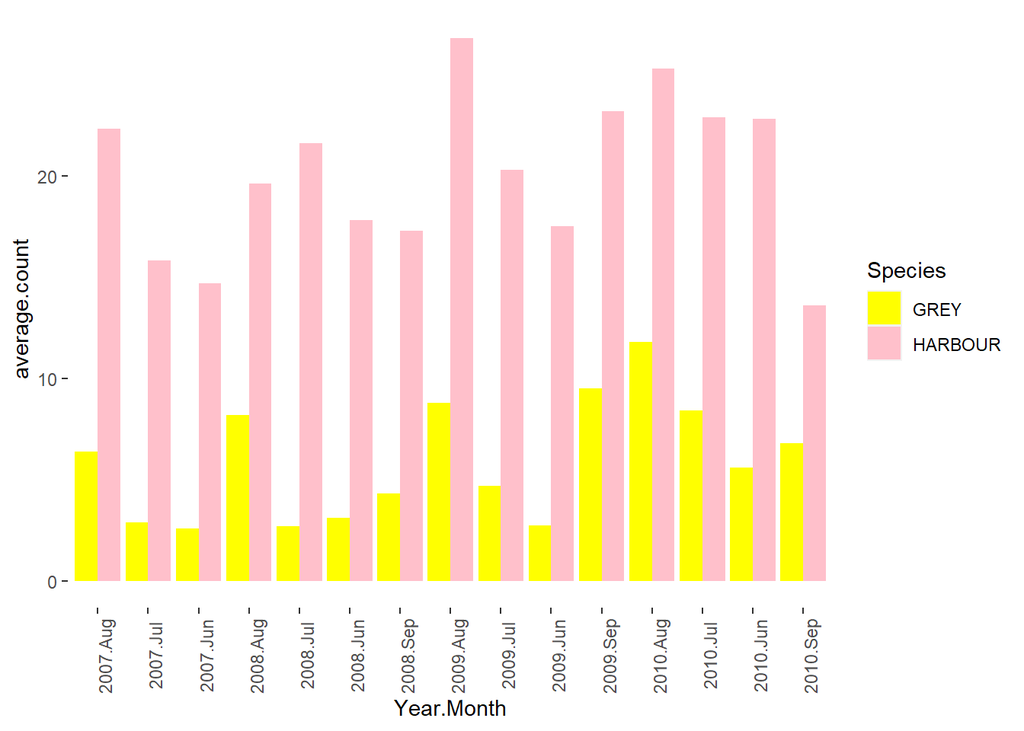

If you look at the graph of average count of each species in a particular month everywhere we can see that the existence of herbal species are way more than the gray species. Therefore we can say that the herbal species are more common than the gray species.In order to find the significant differences between the species we need to find the error species for particular month in each year using SummarySE() function.

| Year.Month | Species | N | average.count | sd | se | ci |
| --- | --- | --- | --- | --- | --- | --- |
| 2007.Aug | GREY | 7 | 1.2857143 | 2.2886885 | 0.8650430 | 2.1166839 |
| 2007.Aug | HARBOUR | 7 | 6.3428571 | 8.2679818 | 3.1250034 | 7.6466079 |
| 2007.Jul | GREY | 7 | 0.8714286 | 1.2051477 | 0.4555030 | 1.1145757 |
| 2007.Jul | HARBOUR | 7 | 5.1714286 | 6.0939080 | 2.3032807 | 5.6359249 |
| 2007.Jun | GREY | 7 | 0.7142857 | 0.9599107 | 0.3628121 | 0.8877693 |
| 2007.Jun | HARBOUR | 7 | 4.2714286 | 6.9254878 | 2.6175883 | 6.4050079 |

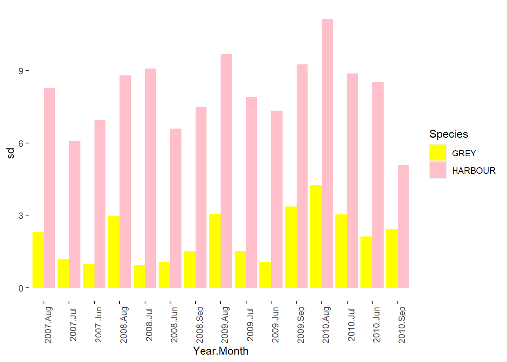

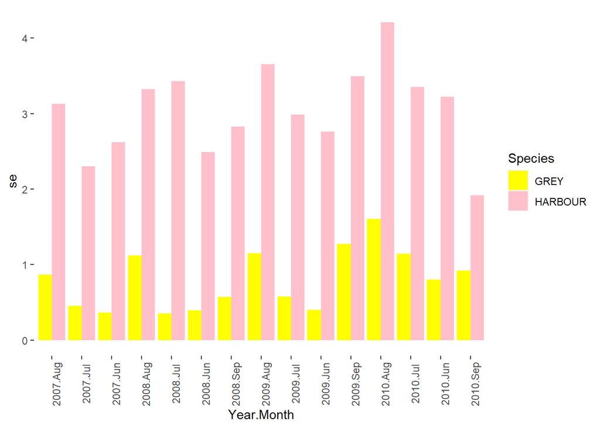

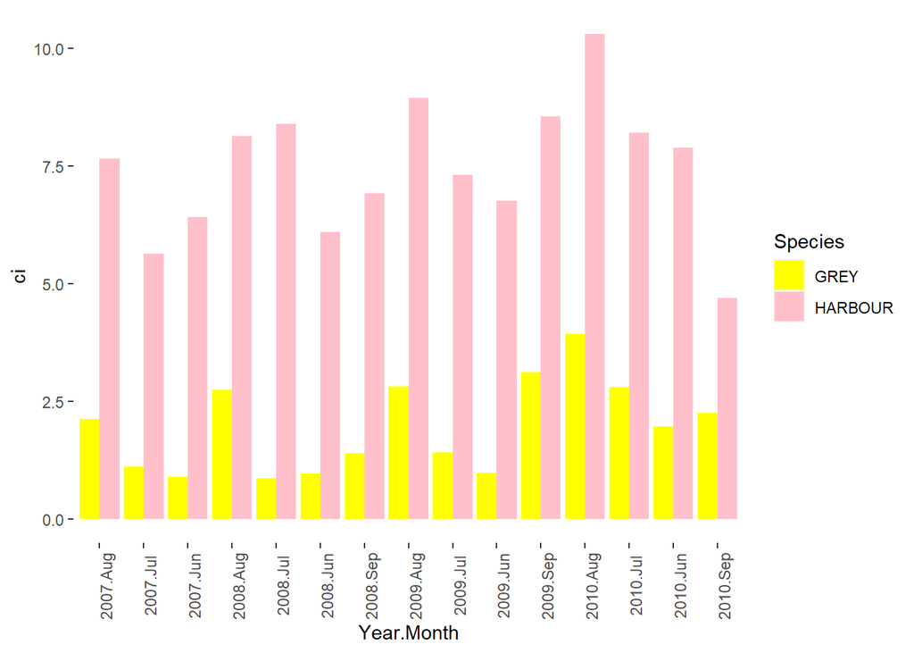

If we check summary data we can find that the date of it consists of count, mean, standard deviation, standard error of mean and confidence interval. in order to find more detailed information we can plot the significant errors graph using ggplot2 in order to find significant difference between each species

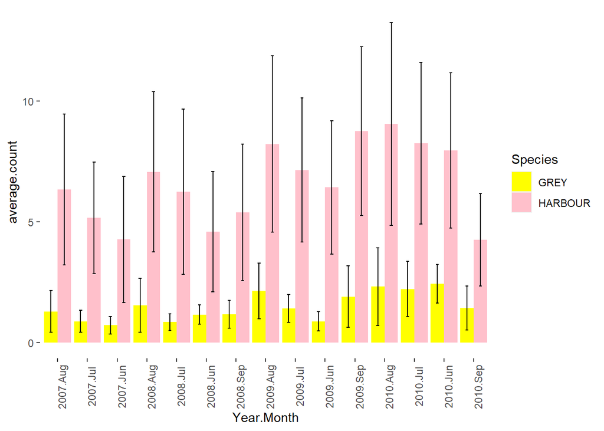

Considering the above graph clearly shows that the graph provides an error bar which significantly shows how each species is using standard error. This clearly signifies difference species for a particular month.

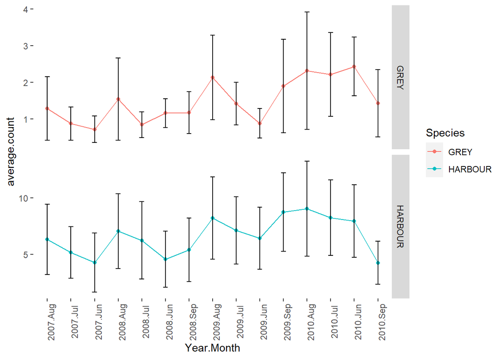

# RESULTS

By summing up, we can say that the data is well explored, analysed and ready to be processed for modelling which will help to give better results for prediction.

# DISCUSSION

In the above data, We were able to successfully explore and analyse and find out the normality distribution of existence for both the species. According to the non parametric test, the most common use of Kruskal Wallis Test is when the data has one nominal variable and one measurement variable but test does not assume that a data han is well distributed and completely align for two parameters which can be mean and standard deviation and also it is called as one way anova(Biostathandbook, One Way Annovas). also this test assumes that the null hypothesis of mean groups are same. therefore if distribution groups are same, the Kruskal wallis test will not show a significant difference in their distribution. Yet, the test does not considered that the data are normally distributed, which can be a big advantage but 800 data has different groups different variants the test will give inaccurate result. Therefore, if the distribution is different and variant is different we can use anova test for accurate results

### REFERENCES

The Kruskal-Wallis One-way Ananysis of Variance by Ranks –Analysis of k-Between-Group Data with a Quantitative Response Variable. Available from : https://psych.unl.edu/psycrs/handcomp/hckw.PDF. [Accessed at 20th December 2020] Biostathandbook.com, http://www.biostathandbook.com/kruskalwallis.html [Accessed at 23d December 2020]